# Lab 07 - Nonparametric Regression

where M denotes the order of the spline, $\xi_{\ell}$ the $l$-th knot and $\left(A\right)_{+}=\max(A, 0)$, we can actually hard code the same model as `model_cubic_splines_2`

```r
# Define trunc power basis
M <- 4 # cubic spline
X_powers <- poly(Prestige$income,degree = (M-1),raw = TRUE)
X_trunc_powers <- sapply(knots, function(k) (Prestige$income-k)^(M-1)*(Prestige$income>k))
X_manual_cubic_splines <- cbind(X_powers, X_trunc_powers)

# Fit the model with OLS
model_cubic_splines_2_manual <- lm(Prestige$prestige ~ X_manual_cubic_splines)

# Construct the new_data_manual object
new_data_manual_powers <- poly(new_data[,1],degree = 3,raw = TRUE)
new_data_manual_trunc_powers <- sapply(knots, function(k) (new_data[,1]-k)^3*(new_data[,1]>k))
new_data_manual <- cbind(new_data_manual_powers, new_data_manual_trunc_powers)

# Make predictions

preds_manual_cubic_splines <- c(cbind(1,new_data_manual)%*%model_cubic_splines_2_manual$coefficients)

# Compare with the previous solution
all(dplyr::near(preds$fit,preds_manual_cubic_splines))
```

```
## [1] TRUE
```

Apart from the considerable coding effort with respect to using the built-in `bs()` function, values in the coefficients vector and in the design matrix get absurdly low and high in our hard-coded solution… Let us stick with B-spline bases from now on!

How to avoid weird behavior at the boundaries of the domain? We can employ **natural splines**.

**Recall**:

- A Spline is a Piecewise Polynomial regression constrained to be continuous at its knots.
- A Natural Spline is a Spline such that:
  - Aimed at reducing variance at boundaries of the domain.
  - There is a Polynomial of degree $k$ in each “interior” interval of the partition induced by the knots.
  - There is a Polynomial of degree $\frac{k-1}{2}$ on the boundary intervals.
  - Continuos derivatives at the knots.
  - The spline basis is orthonormal.
- A Smoothing Spline is a Natural Spline with a curvature penalty in the objective function.

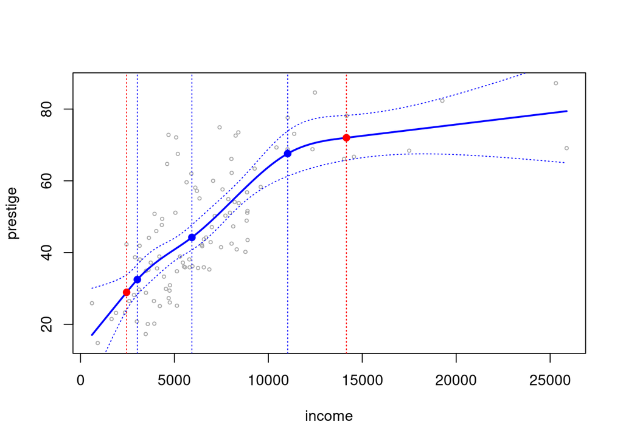

```r
knots <- quantile(Prestige$income,probs=c(0.1,0.5,0.9))
boundary_knots <- quantile(Prestige$income,probs=c(0.05,0.95))

model_ns=lm(prestige ~ ns(income,knots=knots,Boundary.knots=boundary_knots), data=Prestige) #defaults to three knots
preds=predict(model_ns, new_data,se=T)
se.bands=cbind(preds$fit +2* preds$se.fit ,preds$fit -2* preds$se.fit)

with(Prestige, plot(income ,prestige ,xlim=range(new_data$income) ,cex =.5, col =" darkgrey " ))
lines(new_data$income,preds$fit ,lwd =2, col =" blue")
matlines(new_data$income, se.bands ,lwd =1, col =" blue",lty =3)

knots_pred=predict(model_ns,list(income=knots))
points(knots,knots_pred, col='blue',pch=19)
boundary_pred <- predict(model_ns,list(income=boundary_knots))
points(boundary_knots,boundary_pred,col='red',pch=19)
abline(v = knots, lty=3, col="blue")
abline(v = boundary_knots, lty=3, col="red")
```

Clearly, the specification of knots can be non-quantile driven in general.

### Exercise

Play around with the splines functions, applying them to the Wage dataset.

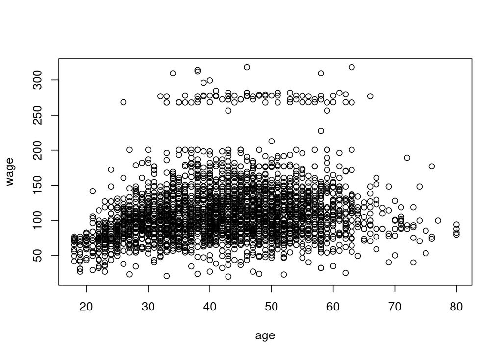

```r
data(Wage)
with(Wage, plot(age,wage))
```

## Smoothing splines

With smoothing splines we look for a function $f(\cdot)$ that makes $RSS=\sum_{i=1}^n(y_i-f(x_i))^2$ small, but that is also smooth. That is, we aim at minimizing

$$\begin{equation}
\operatorname{RSS}(f,
\lambda)=\sum_{i=1}^{n}\left\{y_{i}-f\left(x_{i}\right)\right\}^{2}+\lambda
\int\left\{f^{\prime \prime}(t)\right\}^{2} d t
\end{equation}$$

This is operationally done by performing a penalized regression over the natural spline basis, placing knots at all the inputs. This means that, remarkably, the problem defined on an infinite-dimensional function space has a finite-dimensional, unique minimizer which is a natural cubic spline! This result is not even difficult to prove (see Theorem 2.3 of Nonparametric Regression and Generalized Linear Models: A Roughness Penalty Approach by Green and Silverman) This is automatically performed in R through the `smooth.spline` function.

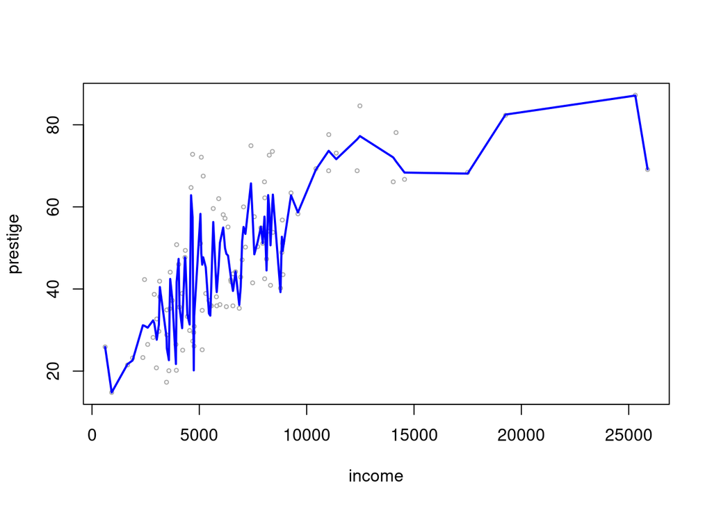

```r
fit_smooth_spline <- with(Prestige, smooth.spline(income,prestige,df=100))
with(Prestige, plot(income ,prestige, cex =.5, col =" darkgrey "))
lines(fit_smooth_spline,col="blue",lwd=2)
```

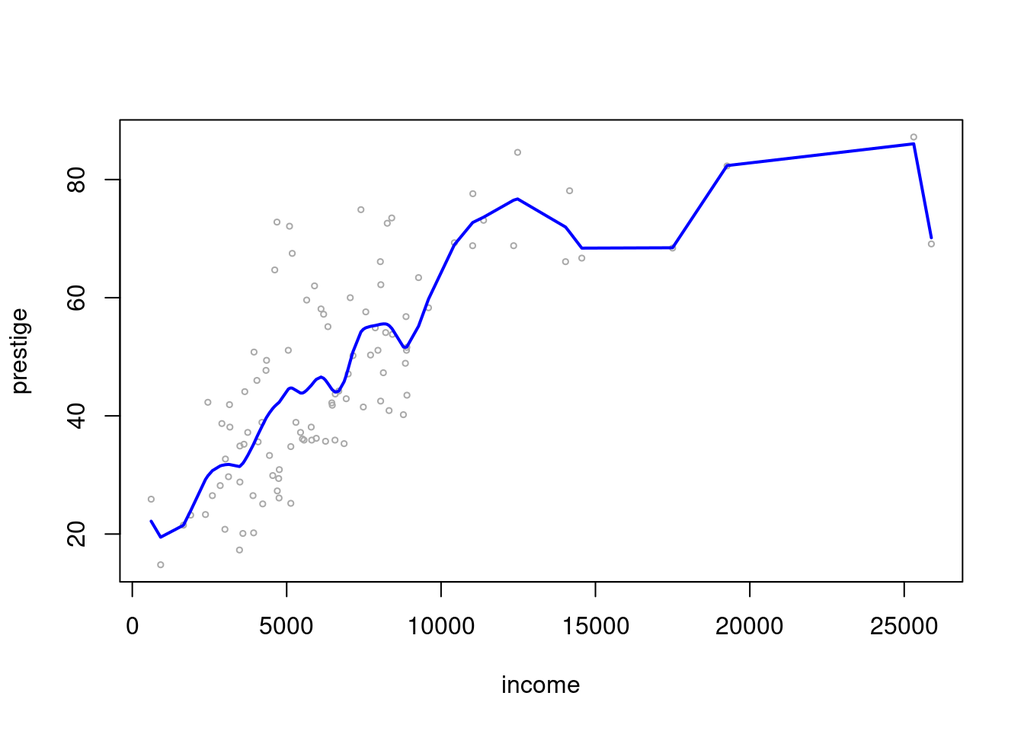

```r
fit_smooth_spline <- with(Prestige, smooth.spline(income,prestige,df=20))
with(Prestige, plot(income ,prestige, cex =.5, col =" darkgrey "))
lines(fit_smooth_spline,col="blue",lwd=2)
```

Or we can directly specify the value of the smoothing parameter $\lambda$

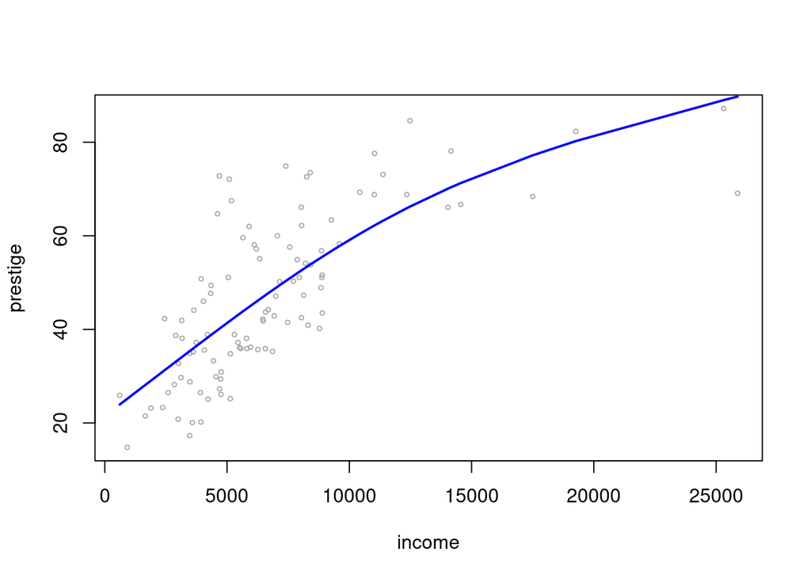

```r
fit_smooth_spline <- with(Prestige, smooth.spline(income,prestige,lambda = 1e-1))
with(Prestige, plot(income ,prestige, cex =.5, col =" darkgrey "))
lines(fit_smooth_spline,col="blue",lwd=2)
```

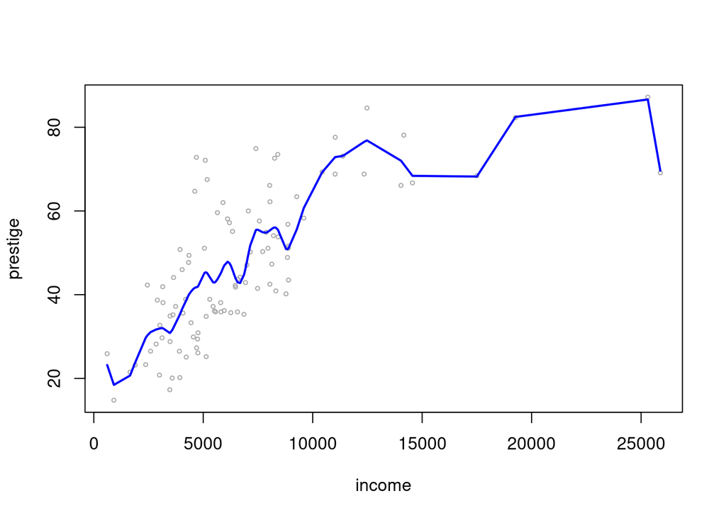

```r
fit_smooth_spline <- with(Prestige, smooth.spline(income,prestige,lambda = 1e-6))
with(Prestige, plot(income ,prestige, cex =.5, col =" darkgrey "))
lines(fit_smooth_spline,col="blue",lwd=2)
```

Generally, one wants to optimize the LOOCV error

$$\begin{equation}
\mathcal{V}_{o}=\frac{1}{n}
\sum_{i=1}^{n}\left(\hat{f}_{i}^{[-i]}-y_{i}\right)^{2}=\frac{1}{n}
\sum_{i=1}^{n}\left(y_{i}-\hat{f}_{i}\right)^{2} /\left(1-A_{i
i}\right)^{2}
\end{equation}$$

or the GCV error

$$\begin{equation}
\mathcal{V}_{g}=\frac{n
\sum_{i=1}^{n}\left(y_{i}-\hat{f}_{i}\right)^{2}}{[n-\operatorname{tr}(\mathbf{A})]^{2}}
\end{equation}$$

where $\boldsymbol{A}$ is the hat matrix of the associated regression problem (see e.g., Section 5.4.1 of The Elements of Statistical Learning by Hastie, Tibshirani and Friedman for further explanation).

```r
fit_smooth_spline_CV <- with(Prestige, smooth.spline(income,prestige,cv = TRUE))
```

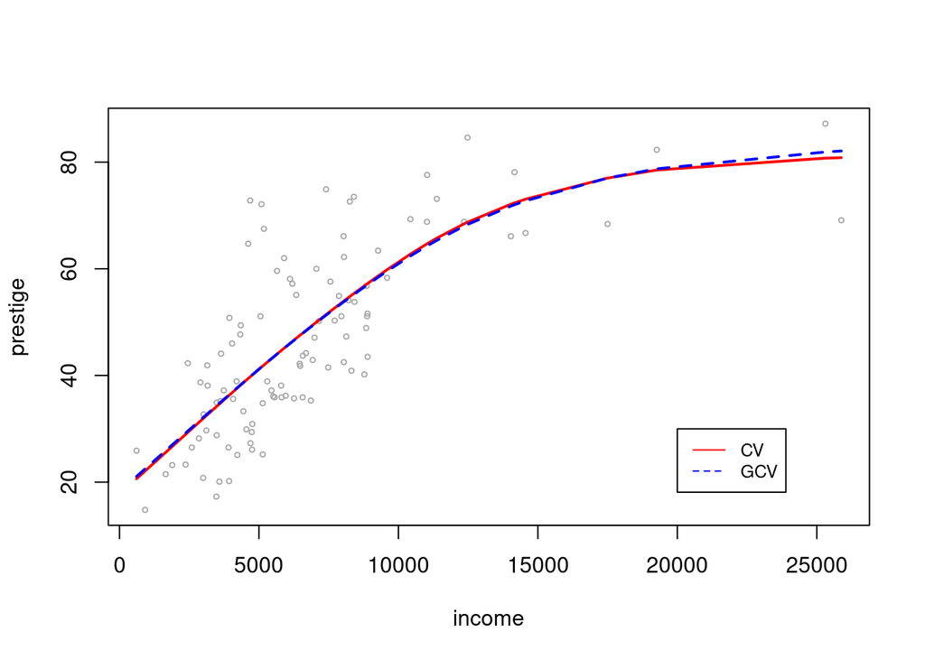

```r
fit_smooth_spline_GCV <- with(Prestige, smooth.spline(income,prestige,cv = FALSE))
with(Prestige, plot(income ,prestige, cex =.5, col =" darkgrey "))
lines(fit_smooth_spline_CV,col="red",lwd=2,lty=1)
lines(fit_smooth_spline_GCV,col="blue",lwd=2, lty=2)
legend(20000, 30, legend=c("CV", "GCV"),
       col=c("red", "blue"), lty=1:2, cex=0.8)
```

Likewise for the previous methods, it is very easy to produce forecasts

```r
predict(fit_smooth_spline_GCV,22000)
```

```
## $x
## [1] 22000
##
## $y
## [1] 80.55615
```